# Table of Contents

## analysis

based on userdataand data

- using Pythonclassificationmodel，regression
- predictionusing Coupon

# 1 dataanalysis

## 1.1 data

- ID recordencoding
- age year
- job
- marital
- default
- returned
- loan using
- coupon_used_in_last6_month monthusing CouponCount
- coupon_used_in_last_month monthusing CouponCount
- coupon_ind using Coupon

```python
#import and data
import pandas as pd
import matplotlib.pyplot as plt
import seaborn as sns
%matplotlib inline

coupon = pd.read_csv('tianmao.csv')
coupon.head()
```

|  | ID | age | job | marital | default | returned | loan | coupon_used_in_last6_month | coupon_used_in_last_month | coupon_ind |
| --- | --- | --- | --- | --- | --- | --- | --- | --- | --- | --- |
| 0 | 1 | 43 | management | married | no | yes | no | 2 | 0 | 0 |
| 1 | 2 | 42 | technician | divorced | no | yes | no | 1 | 1 | 0 |
| 2 | 3 | 47 | admin. | married | no | yes | yes | 2 | 0 | 0 |
| 3 | 4 | 28 | management | single | no | yes | yes | 2 | 0 | 0 |
| 4 | 5 | 42 | technician | divorced | no | yes | no | 5 | 0 | 0 |

```python
#viewdata
coupon.shape
```

```
(25317, 10)
```

```python
#viewdatamissing values
coupon.info()
```

```
RangeIndex: 25317 entries, 0 to 25316
Data columns (total 10 columns):
 #   Column                      Non-Null Count  Dtype
---  ------                      --------------  -----
 0   ID                          25317 non-null  int64
 1   age                         25317 non-null  int64
 2   job                         25317 non-null  object
 3   marital                     25317 non-null  object
 4   default                     25317 non-null  object
 5   returned                    25317 non-null  object
 6   loan                        25317 non-null  object
 7   coupon_used_in_last6_month  25317 non-null  int64
 8   coupon_used_in_last_month   25317 non-null  int64
 9   coupon_ind                  25317 non-null  int64
dtypes: int64(5), object(5)
memory usage: 1.9+ MB
```

## 1.2 Data Cleaning

### 1.2.1 variable

```python
#variablevariable，analysis
#，analysis，processingdefault, returned, loanvariable，job, marital
#default、returned、loanvariablevariableprocessingget_dummies()。
coupon1 = coupon[['default','returned','loan']]
coupon1 = pd.get_dummies(coupon1)
coupon1.head()
```

|  | default_no | default_yes | returned_no | returned_yes | loan_no | loan_yes |
| --- | --- | --- | --- | --- | --- | --- |
| 0 | 1 | 0 | 0 | 1 | 1 | 0 |
| 1 | 1 | 0 | 0 | 1 | 1 | 0 |
| 2 | 1 | 0 | 0 | 1 | 0 | 1 |
| 3 | 1 | 0 | 0 | 1 | 0 | 1 |
| 4 | 1 | 0 | 0 | 1 | 1 | 0 |

```python
#processing and
coupon = pd.concat([coupon, coupon1], axis = 1)
coupon.head()
```

|  | ID | age | job | marital | default | returned | loan | coupon_used_in_last6_month | coupon_used_in_last_month | coupon_ind | default_no | default_yes | returned_no | returned_yes | loan_no | loan_yes |
| --- | --- | --- | --- | --- | --- | --- | --- | --- | --- | --- | --- | --- | --- | --- | --- | --- |
| 0 | 1 | 43 | management | married | no | yes | no | 2 | 0 | 0 | 1 | 0 | 0 | 1 | 1 | 0 |
| 1 | 2 | 42 | technician | divorced | no | yes | no | 1 | 1 | 0 | 1 | 0 | 0 | 1 | 1 | 0 |
| 2 | 3 | 47 | admin. | married | no | yes | yes | 2 | 0 | 0 | 1 | 0 | 0 | 1 | 0 | 1 |
| 3 | 4 | 28 | management | single | no | yes | yes | 2 | 0 | 0 | 1 | 0 | 0 | 1 | 0 | 1 |
| 4 | 5 | 42 | technician | divorced | no | yes | no | 5 | 0 | 0 | 1 | 0 | 0 | 1 | 1 | 0 |

```python
#containsinfo and infodata
coupon.drop(['ID', 'default', 'default_no', 'returned', 'returned_no', 'loan', 'loan_no'], axis = 1, inplace = True)

#coupon_indflag，analysis
coupon = coupon.rename(columns = {'coupon_ind' : 'flag'})
coupon.info()
```

```
RangeIndex: 25317 entries, 0 to 25316
Data columns (total 9 columns):
 #   Column                      Non-Null Count  Dtype
---  ------                      --------------  -----
 0   age                         25317 non-null  int64
 1   job                         25317 non-null  object
 2   marital                     25317 non-null  object
 3   coupon_used_in_last6_month  25317 non-null  int64
 4   coupon_used_in_last_month   25317 non-null  int64
 5   flag                        25317 non-null  int64
 6   default_yes                 25317 non-null  uint8
 7   returned_yes                25317 non-null  uint8
 8   loan_yes                    25317 non-null  uint8
dtypes: int64(4), object(2), uint8(3)
memory usage: 1.2+ MB
```

# 2 variableanalysis

## 2.1 sample0、1

```python
#classificationmodel，sample(flag)0,1
coupon['flag'].value_counts(1)
```

```
0    0.883043
1    0.116957
Name: flag, dtype: float64
```

- classification，0、1Share，0.05，modelprediction
- dataset0、1Share0.05， therefore Distribution

## 2.2

```python
#customerusing couponclassification
summary = coupon.groupby(['flag'])
#various Share
summary.mean()
```

| flag | age | coupon_used_in_last6_month | coupon_used_in_last_month | default_yes | returned_yes | loan_yes |
| --- | --- | --- | --- | --- | --- | --- |
| 0 | 40.819601 | 2.857846 | 0.260378 | 0.018876 | 0.579755 | 0.169037 |
| 1 | 41.809524 | 2.124282 | 0.537994 | 0.008781 | 0.357649 | 0.094563 |

### data0 and 1variable，analysisvariableflagDistribution：

- coupon_used_in_last_month00.26，10.53，descriptionmonthusing couponcustomer，using coupon
- default_yes and loan_yes0hour1hour，description and customertimeusing coupon
- age0 and 1respectively40.8 and 41.8，，descriptionyearminute

## 2.3 visualization

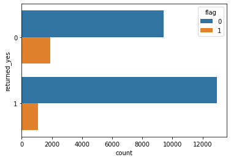

```python
#returned_yesflagDistribution
sns.countplot(y = 'returned_yes', hue = 'flag', data = coupon)
```

- customer，customerusing coupon

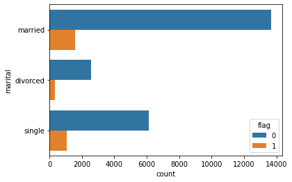

```python
#maritalflagDistribution
sns.countplot(y = 'marital', hue = 'flag', data = coupon)
```

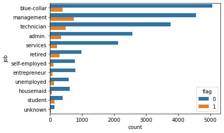

```python
#jobflagDistribution
sns.countplot(y = 'job', hue = 'flag', data = coupon, order = coupon['job'].value_counts().index)
```

- job titlemanagement, technician, blue-collarcustomerusing coupon

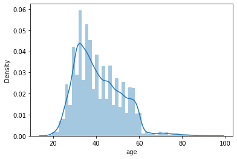

```python
#ageflagDistribution
sns.distplot(coupon['age'])
```

```python
#viewagedataDistribution
coupon['age'].describe()
```

```
count    25317.000000
mean        40.935379
std         10.634289
min         18.000000
25%         33.000000
50%         39.000000
75%         48.000000
max         95.000000
Name: age, dtype: float64
```

- data18 - 95customerusing coupon，using coupon40
- age > 60，dataDistribution，need to minutedataanalysis

```python
#yearminute，yearusing coupon
age60 = coupon[coupon['age'] < 60]
bins = [0, 20, 40, 60]
labels = ['<20','<40','<60']
age60['age_new'] = pd.cut(age60.age, bins, right=False,labels = labels)
age60.groupby(['age_new'])['age'].describe()
```

| age_new | count | mean | std | min | 25% | 50% | 75% | max |
| --- | --- | --- | --- | --- | --- | --- | --- | --- |
| <20 | 25.0 | 18.760000 | 0.435890 | 18.0 | 19.0 | 19.0 | 19.0 | 19.0 |
| <40 | 13063.0 | 32.569624 | 4.130196 | 20.0 | 30.0 | 33.0 | 36.0 | 39.0 |
| <60 | 11215.0 | 48.416942 | 5.720111 | 40.0 | 43.0 | 48.0 | 53.0 | 59.0 |

```python
age60['age_new'].describe()
```

```
count     24303
unique        3
top         <40
freq      13063
Name: age_new, dtype: object
```

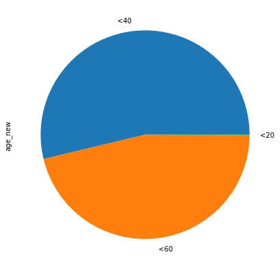

```python
#age60['age_new']，data
plt.figure(figsize=[9,7])
age60['age_new'].value_counts().plot.pie()
plt.show()
```

- 20 - 40using coupon
- 18，32，48respectivelyyearusing couponyearmean

# 3 related and visualization

```python
#flagvariable，variable
coupon.corr()[['flag']].sort_values('flag', ascending = False)
```

|  | flag |
| --- | --- |
| flag | 1.000000 |
| coupon_used_in_last_month | 0.116550 |
| age | 0.029916 |
| default_yes | -0.024608 |
| loan_yes | -0.065231 |
| coupon_used_in_last6_month | -0.075173 |
| returned_yes | -0.143589 |

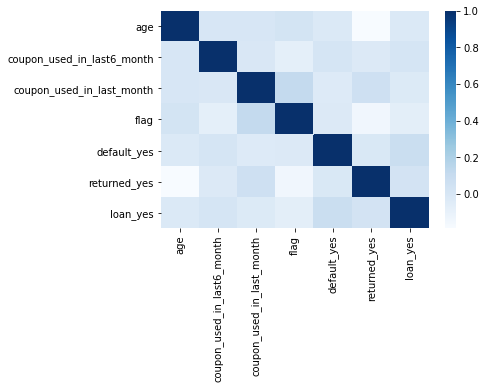

```python
sns.heatmap(coupon.corr(), cmap = 'Blues')
```

- flagcoupon_used_in_last_month, agerelated
- flagcoupon_used_in_last6_month, returned_yesrelated
- variableflagrelated ，analysis， therefore

# 4 regressionmodel and evaluation

## 4.1 model

### 4.1.1 training set and test set

```python
#variablex and variabley
x = coupon[['coupon_used_in_last_month', 'returned_yes', 'loan_yes']]
y = coupon['flag']
```

```python
#sklearn，training set and test set
from sklearn.model_selection import train_test_split
x_train, x_test, y_train, y_test = train_test_split(x, y, test_size = 0.3, random_state = 100) #training set and test set70/30

#sklearnregression
from sklearn import linear_model
lr = linear_model.LogisticRegression()

#
lr.fit(x_train, y_train)
```

```
LogisticRegression()
```

### 4.1.2 viewmodelresult

```python
#view
lr.coef_
```

```
array([[ 0.38674154, -0.95906584, -0.56226592]])
```

- coupon_used_in_last_month01hour，using couponusing coupone0.38，customer1.46
- returned_yes10hour，using couponusing couponcustomer0.38
- loan_yes10hour，using couponusing couponcustomer0.57
- ，monthusing couponcustomer、customer and using coupon。

```python
#view
lr.intercept_
```

```
array([-1.63641623])
```

## 4.2 Model Evaluation

### 4.2.1 evaluation：calculateAccuracy

```python
#through training set and test setvariablex，respectivelycalculateprediction
y_pred_train = lr.predict(x_train)
y_pred_test = lr.predict(x_test)
```

```python
#training setConfusion Matrix
from sklearn import metrics
metrics.confusion_matrix(y_train, y_pred_train)
```

```
array([[15596,    27],
       [ 2092,     6]], dtype=int64)
```

```python
#viewtraining setaccuracy
metrics.accuracy_score(y_train, y_pred_train)
```

```
0.8804243552846904
```

```python
#test setConfusion Matrix
metrics.confusion_matrix(y_test, y_pred_test)
```

```
array([[6722,   11],
       [ 862,    1]], dtype=int64)
```

```python
#viewtest setaccuracy
metrics.accuracy_score(y_test, y_pred_test)
```

```
0.8850710900473934
```

### 4.2.2 evaluation：ROC and AUC

```python
#using aucevaluationmodel
from sklearn.metrics import roc_curve, auc
fpr,tpr,threshold = roc_curve(y_train, y_pred_train)
roc_auc = auc(fpr,tpr)

print(roc_auc)
```

```
0.5005658226636232
```

## 4.3 model

```python
#variablereturned_yes
x = coupon[['coupon_used_in_last_month', 'returned_yes', 'loan_yes', 'coupon_used_in_last6_month', 'default_yes', 'age']]
y = coupon['flag']
```

```python
#sklearn，training set and test set
from sklearn.model_selection import train_test_split
x_train, x_test, y_train, y_test = train_test_split(x, y, test_size = 0.3, random_state = 100) #training set and test set70/30

#sklearnregression
from sklearn import linear_model
lr = linear_model.LogisticRegression()

#
lr.fit(x_train, y_train)
```

```
LogisticRegression()
```

```python
lr.coef_
```

```
array([[ 0.43301916, -0.98378705, -0.5325839 , -0.16775231, -0.53714092,
         0.00114021]])
```

```python
#using aucevaluationmodel
from sklearn.metrics import roc_curve, auc
fpr,tpr,threshold = roc_curve(y_train, y_pred_train)
roc_auc = auc(fpr,tpr)

print(roc_auc)
```

[output not shown]

# 5

## 5.1 useranalysis

- data18 - 95customerusing coupon，using coupon40
- 20 - 40using coupon
- 18，32，48respectivelyyearusing couponyearmean

## 5.2 Couponusing analysis - user

- coupon_used_in_last_month00.26，10.53，descriptionmonthusing couponcustomer，using coupon
- default_yes and loan_yes0hour1hour，description and customertimeusing coupon
- customer，customerusing coupon
- customerusing coupon and customerusing coupon
- job titlemanagement, technician, blue-collarcustomerusing coupon
- flagcoupon_used_in_last_month, agerelated
- flagcoupon_used_in_last6_month, returned_yesrelated
- variableflagCorrelation